# lab-6(faceting)

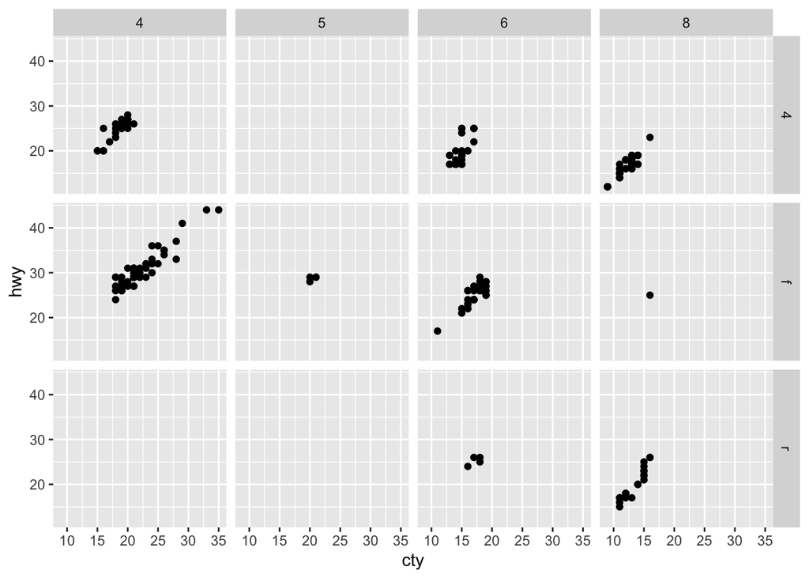

```r
ggplot(data = mpg, aes(cty,hwy))+
  geom_point()+
  facet_grid(drv~cyl)
```

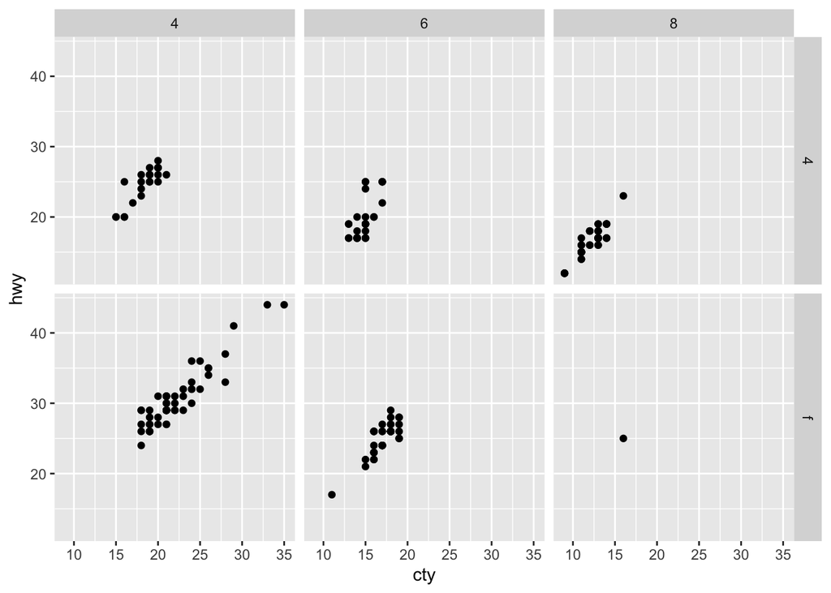

```r
mpg1 <- subset(mpg, cyl != 5 & drv %in% c("4", "f"))
ggplot(data = mpg1,aes(cty,hwy))+
  geom_point()+
  facet_grid(drv~cyl)
```

This code filters the mpg dataset to include only cars without 5 cylinders and with either four-wheel or front-wheel drive. It then creates a faceted scatter plot of engine displacement (displ) vs. highway miles per gallon (hwy), adding linear regression lines to show the trend. The plot is divided into a grid where each subplot represents a specific combination of cylinder count (cyl) and drive type (drv). Additionally, it includes marginal plots that summarize the trends across all cylinder counts and drive types

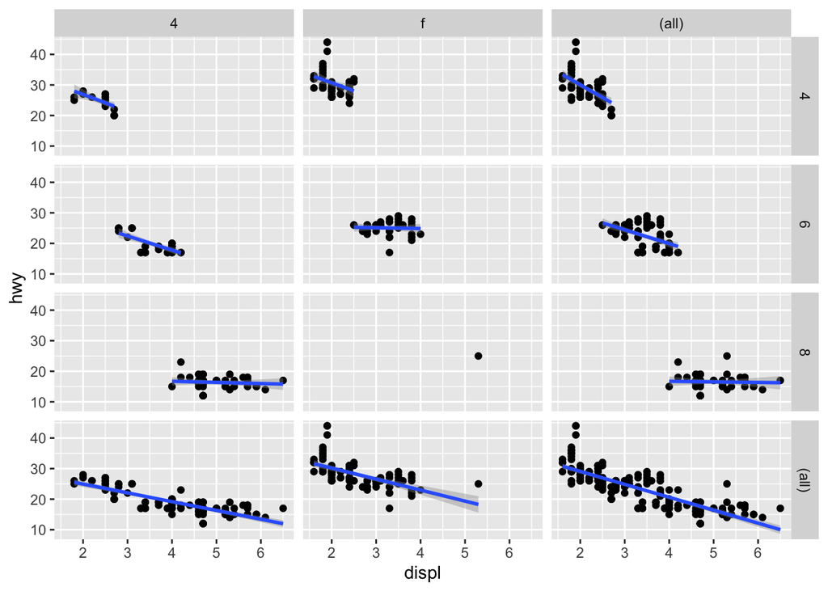

```r
mpg2 <- subset(mpg, cyl!=5 & drv %in% c("4","f"))
p <- ggplot(data = mpg2, aes(displ, hwy)) + geom_point() + geom_smooth(method = "lm")
p + facet_grid(cyl ~ drv, margins = T)
```

This code filters the mpg dataset to exclude cars with 5 cylinders and to include only those with four-wheel or front-wheel drive. It then creates a faceted scatter plot of engine displacement (displ) vs. highway miles per gallon (hwy), adding color-coded linear regression lines for each drive type (drv). The plot is divided into a grid based on cylinder count (cyl) and drive type, with marginal plots that summarize trends across all cylinder counts and drive types

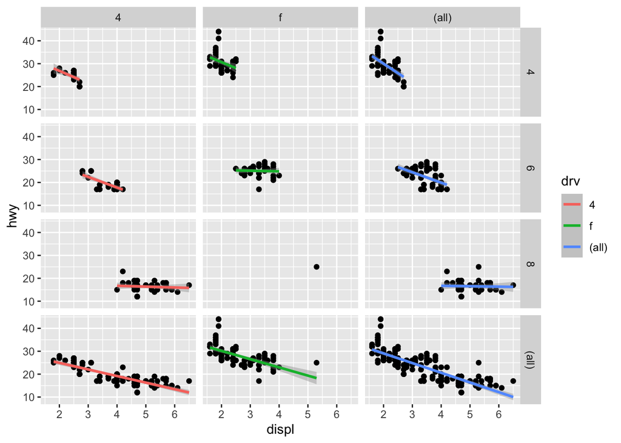

```r
mpg2 <- subset(mpg, cyl != 5 & drv %in% c("4", "f"))
p <- ggplot(data = mpg2, aes(displ, hwy)) + geom_point() + geom_smooth(aes(colour = drv), method = "lm")
p + facet_grid(cyl ~ drv, margins = T)
```